# AAPL

Valery Andruynichev

04 dec 2017 year

Проведем анализ одномерного динамического ряда акций Apple

Загрузим необходимые компоненты

```r
library(reshape2) # Манипулирование данными
library(forecast) # Построение модели  ARIMA
library(tseries) #  Проверка стационарности
```

Для анализа загрузим файл .csv

Укажем папку с файлом

```r
dir<-"D://GH//AAPL//"
```

Загрузка файла .csv

```r
ap<-read.csv(paste(dir,'AAPL.csv',sep=''),stringsAsFactors = FALSE)
head(ap)
```

```
##         Date   Open   High    Low  Close Adj.Close   Volume
## 1 2014-12-31 112.82 113.13 110.21 110.38  104.4884 41403400
## 2 2015-01-02 111.39 111.44 107.35 109.33  103.4944 53204600
## 3 2015-01-05 108.29 108.65 105.41 106.25  100.5788 64285500
## 4 2015-01-06 106.54 107.43 104.63 106.26  100.5883 65797100
## 5 2015-01-07 107.20 108.20 106.70 107.75  101.9988 40105900
## 6 2015-01-08 109.23 112.15 108.70 111.89  105.9178 59364500
```

Просмотрим характеристики даныых

```r
apply(ap,2,class)
```

```
##        Date        Open        High         Low       Close   Adj.Close
## "character" "character" "character" "character" "character" "character"
##      Volume
## "character"
```

Поменяем класс данных на числовые

```r
ap[,c(2:7)]<-sapply(ap[,c(2:7)],function(x) as.numeric (x))
ap[,1]<-as.Date(ap[,1])
ap<-ap[ap$Date>'2015-01-01',]
```

Толбец с дататами присвоем класс “дата” и ограничем выборку с 2015-01-01

```r
ap[,1]<-as.Date(ap[,1])
ap<-ap[ap$Date>'2015-01-01',]
```

```r
apply(ap,2,class)
```

```
##        Date        Open        High         Low       Close   Adj.Close
## "character" "character" "character" "character" "character" "character"
##      Volume
## "character"
```

```r
head(ap)
```

```
##         Date   Open   High    Low  Close Adj.Close   Volume
## 2 2015-01-02 111.39 111.44 107.35 109.33  103.4944 53204600
## 3 2015-01-05 108.29 108.65 105.41 106.25  100.5788 64285500
## 4 2015-01-06 106.54 107.43 104.63 106.26  100.5883 65797100
## 5 2015-01-07 107.20 108.20 106.70 107.75  101.9988 40105900
## 6 2015-01-08 109.23 112.15 108.70 111.89  105.9178 59364500
## 7 2015-01-09 112.67 113.25 110.21 112.01  106.0314 53699500
```

Построим график цен закрытия

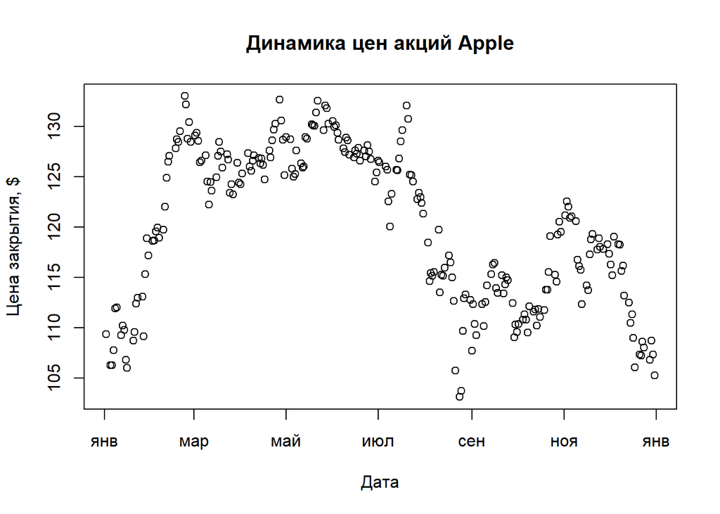

```r
plot(ap$Date,ap$Close, main='Динамика цен акций Apple',ylab = "Цена закрытия, $", xlab = "Дата")
```

И граик логарифма цен закрытия

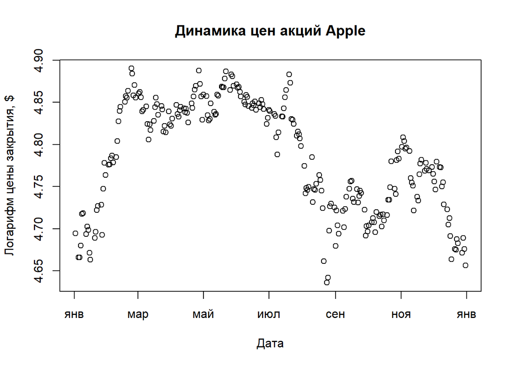

```r
plot(ap$Date,log(ap$Close), main='Динамика цен акций Apple',ylab = "Логарифм цены закрытия, $", xlab = "Дата")
```

Проведем проверку данных Apple

Проверим времянной ряд на стационарность с уровнем значимости $\alpha$ =0.05

```r
adf.test(log(ap$Close))
```

```
##
##  Augmented Dickey-Fuller Test
##
## data:  log(ap$Close)
## Dickey-Fuller = -2.6719, Lag order = 6, p-value = 0.2929
## alternative hypothesis: stationary
```

P-value больше уровня значимости, гипотеза об отсутствии стационарности ряда принимается. Это говорит нам об присутсвии тренда.

Проверим первые разности логарифмов цен и проверим на стационарность получившийся ряд. Для этого создадим вспомогательный массив

```r
ap_dif<-data.frame(Date = ap$Date[-1],Close=diff(log(ap$Close),lag = 1)) #  Создание вспомогательного массива с первыми разности
head(ap_dif)
```

```
##         Date         Close
## 1 2015-01-05 -2.857604e-02
## 2 2015-01-06  9.413204e-05
## 3 2015-01-07  1.392479e-02
## 4 2015-01-08  3.770251e-02
## 5 2015-01-09  1.071934e-03
## 6 2015-01-12 -2.494934e-02
```

Проверим получившийся ряд на стационарность

```r
adf.test(ap_dif$Close)
```

```
##
##  Augmented Dickey-Fuller Test
##
## data:  ap_dif$Close
## Dickey-Fuller = -6.4894, Lag order = 6, p-value = 0.01
## alternative hypothesis: stationary
```

P-value меньше уровня значимости, гипотеза об отсутствии стационарности ряда не принимается. Это говорит нам об отсутсвии тренда.

Построим грайик созданного ряда

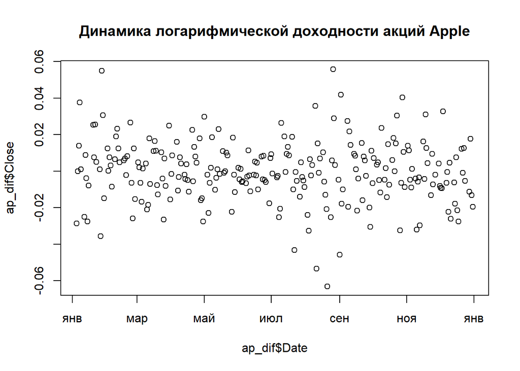

```r
plot(ap_dif$Date,ap_dif$Close, main= 'Динамика логарифмической доходности акций Apple')
```

По графику мы также видим, что тренд в данном ряде отсутствует

Построим автокорреляционную и частную автокорреляционную функции для ряда доходностей акций Aple

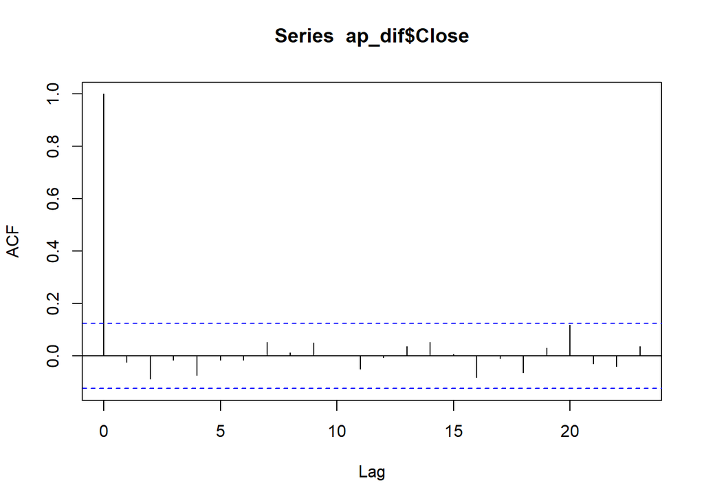

```r
acf(ap_dif$Close)
```

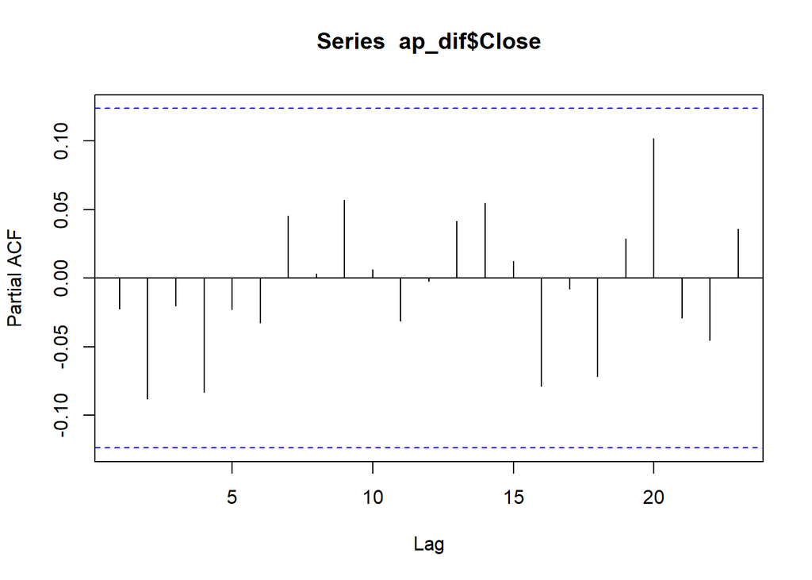

```r
pacf(ap_dif$Close)
```

Получим модель ARIMA для логарифмических доходностей

Для получения модели ARIMA jсуществим автоматический выбор модели с помощью функции auto.arima библиотеки forecast.

```r
m<-auto.arima(ap_dif$Close)
m
```

```
## Series: ap_dif$Close
## ARIMA(0,0,0) with zero mean
##
## sigma^2 estimated as 0.0002835:  log likelihood=668.96
## AIC=-1335.92   AICc=-1335.9   BIC=-1332.39
```

В качестве примера можно применить автоматический выбор модели для исходного ряда логарифмов цен. Результат полностью совпал с предыдущей моделью, при этом порядок интеграции равен 1, что еще раз подтверждает результат предыдущей модели и необходимость преобразования исходного ряда логарифмов цен.

```r
mlog<-auto.arima(log(ap$Close))
mlog
```

```
## Series: log(ap$Close)
## ARIMA(0,1,0)
##
## sigma^2 estimated as 0.0002836:  log likelihood=668.96
## AIC=-1335.92   AICc=-1335.9   BIC=-1332.39
```